# BF528__FINAL_PROJECT_REPORT__Mohammad_Gharandouq

# Figure 6B: cDC2 differential accessibility heatmap

In cDC2 cells, ATAC-seq identified 759 differentially accessible regions (p < 0.01), again with more regions gaining accessibility upon HDAC1 deletion than losing accessibility. The heatmaps show clear genotype-dependent accessibility differences, with gained regions exhibiting elevated ATAC signal in knockout samples and lost regions enriched in wild-type samples. Although fewer DARs were detected compared to cDC1s, the overall accessibility patterns and direction of change are consistent with those described in the original publication.

While the absolute number of differentially accessible regions identified in this analysis is slightly lower than reported in the original study (1,680 vs. 1,863 DARs for cDC1 and 759 vs. 843 DARs for cDC2 at p < 0.01), the overall magnitude, directionality, and chromatin accessibility patterns are highly consistent. These minor differences are expected given independent reprocessing of raw sequencing data, differences in analysis parameters, and the use of a different reference genome build (mm39 in this study versus mm10 in the original publication).

# Figure 6C&E:

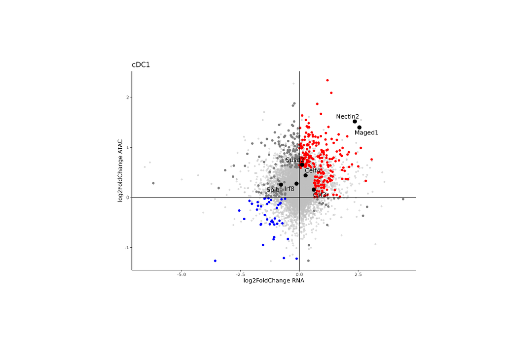

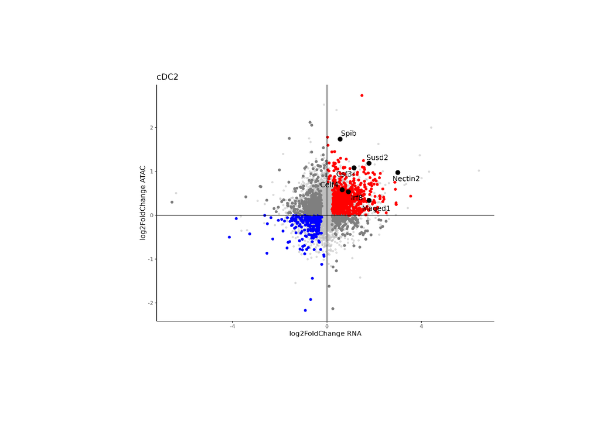

# Comment for Figure 6C&E:

Correlation analysis between chromatin accessibility and gene expression revealed a strong concordance between ATAC-seq and RNA-seq changes following HDAC1 deletion. In cDC1 cells, genes such as Maged1 and Nectin2 exhibited simultaneous increases in chromatin accessibility and transcription, indicating direct regulatory effects. In cDC2 cells, coordinated increases were observed for Spib, Nectin2, Csf3r, and Celf4, consistent with the original study. These results support a model in which HDAC1 regulates dendritic cell identity by modulating accessibility at regulatory regions of key lineage-defining genes.

ATAC-seq differential accessibility was quantified using DiffBind, which produces log2 fold-change estimates for chromatin accessibility between conditions. Peaks were annotated to genes using ChIPseeker to obtain gene-level ATAC-seq measurements. RNA-seq count data were downloaded from GEO and analyzed using DESeq2 to generate gene-level log2 fold-change and adjusted p-values.

Gene-level ATAC-seq and RNA-seq results were then integrated by matching gene symbols, and log2 fold-changes from both assays were visualized jointly to assess concordance between changes in chromatin accessibility and transcription. Genes were highlighted if they were statistically significant in either dataset, defined as padj < 0.05 for RNA-seq or p-value < 0.01 for ATAC-seq, consistent with thresholds used in the original study.

# Figure 6D&F

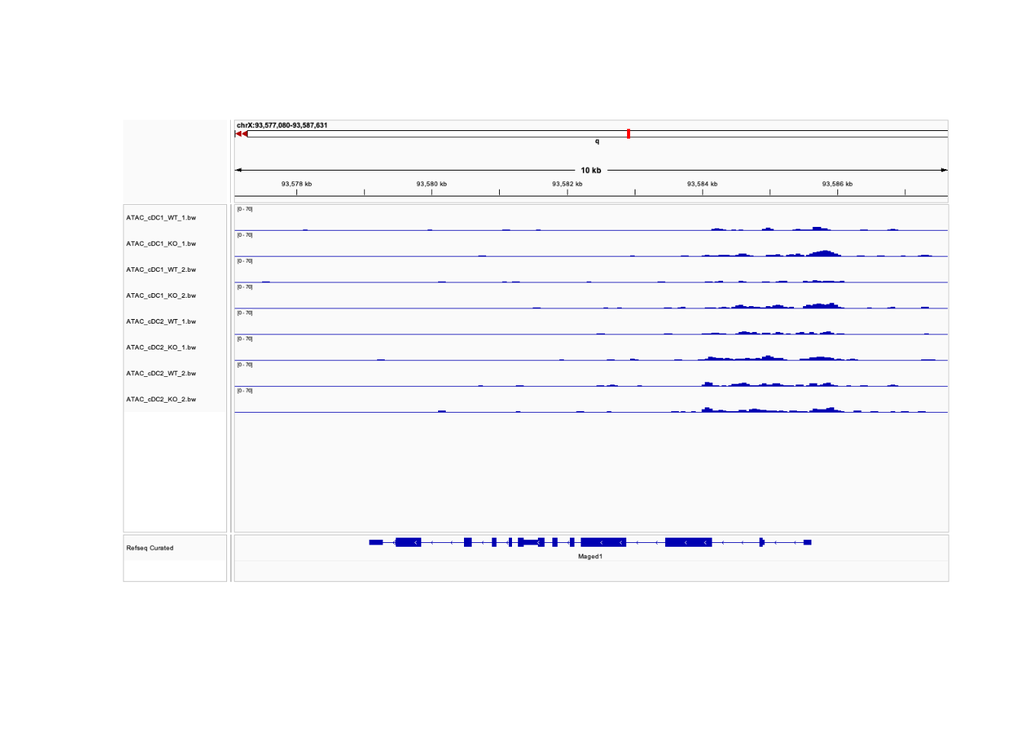

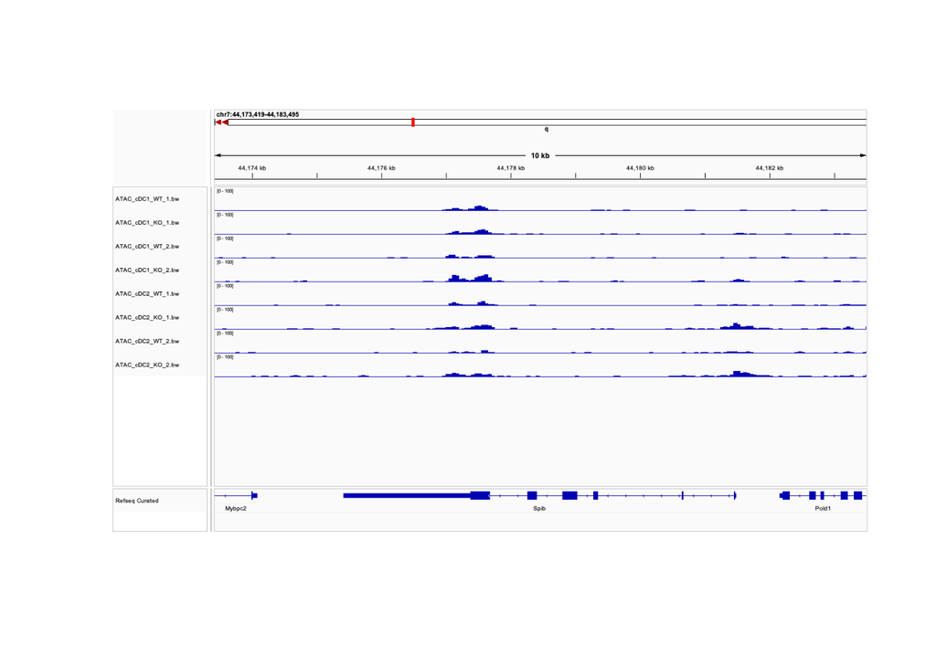

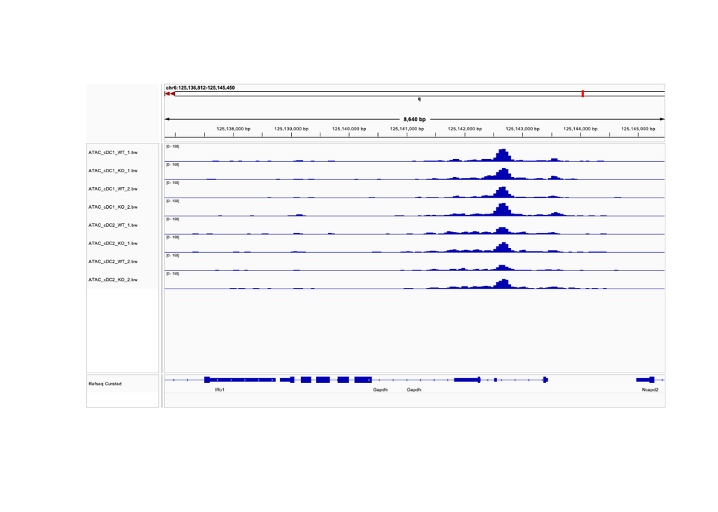